# Module 4: Peer Reviewed Assignment

### Outline:

The objectives for this assignment:

1. Understand mean intervals and Prediction Intervals through read data applications and visualizations.
2. Observe how CIs and PIs change on different data sets.
3. Observe and analyze interval curvature.
4. Apply understanding of causation to experimental and observational studies.

General tips:

1. Read the questions carefully to understand what is being asked.
2. This work will be reviewed by another human, so make sure that you are clear and concise in what your explanations and answers.

```python
# This cell loads the necesary libraries for this assignment
library(tidyverse)
library(ggplot2)
```

## Problem 1: Interpreting Intervals

For this problem, we're going to practice creating and interpreting Confidence (Mean) Intervals and Prediction Intervals. To do so, we're going to use data in U.S. State Wine Consumption (millions of liters) and Population (millions).

#### 1. (a) Initial Inspections

Load in the data and create a scatterplot with `population` on the x-axis and `totWine` on the y-axis. For fun, set the color of the point to be `#CFB87C`.

A data.frame: 10 × 4

|  | State <fct> | pcWine <dbl> | pop <dbl> | totWine <dbl> |
| --- | --- | --- | --- | --- |
| 1 | Alabama | 6.0 | 4.829479 | 28.976874 |
| 2 | Alaska | 10.9 | 0.736879 | 8.031981 |
| 3 | Arizona | 9.7 | 6.624617 | 64.258785 |
| 4 | Arkansas | 4.2 | 2.958663 | 12.426385 |
| 5 | California | 14.0 | 38.335203 | 536.692842 |
| 6 | Colorado | 8.7 | 5.267603 | 45.828146 |
| 7 | Connecticut | 14.4 | 3.596003 | 51.782443 |
| 8 | Delaware | 13.5 | 0.925395 | 12.492833 |
| 9 | District of Columbia | 25.7 | 0.649165 | 16.683540 |
| 10 | Florida | 12.4 | 19.582022 | 242.817073 |

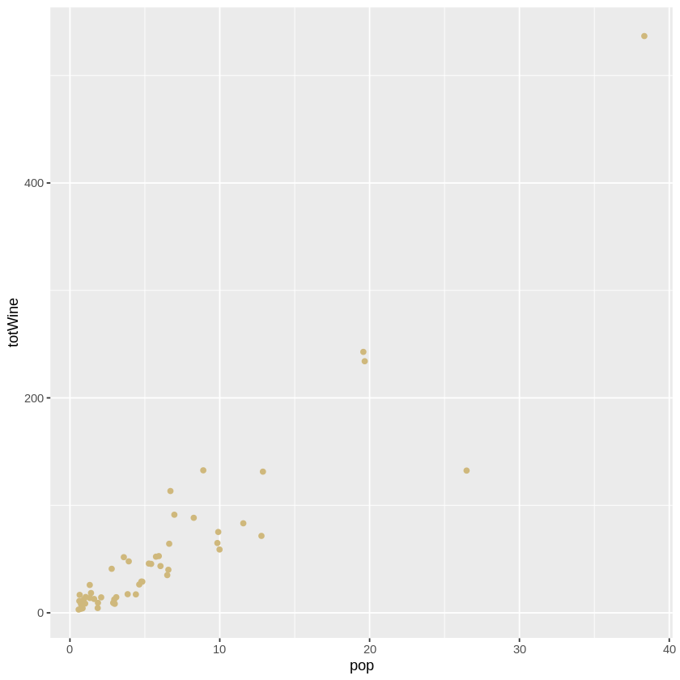

```python
# Load the data
wine.data = read.csv("wine_state_2013.csv")
head(wine.data, n = 10)
# Your Code Here
wine_plot <- ggplot(data = wine.data, aes(x=pop, y=totWine)) +
                geom_point(color='#CFB87C')
wine_plot
```

#### 1. (b) Confidence Intervals

Fit a linear regression with `totWine` as the response and `pop` as the predictor. Add the regression line to your scatterplot. For fun, set its color to gold with `col=#CFB87C`. Add the $90\%$ Confidence Interval for the regression line to the plot.

Then choose a single point-value population and display the upper and lower values for the Confidence Interval at that point. In words, explain what this interval means for that data point.

A data.frame: 1 × 4

|  | State <fct> | pcWine <dbl> | pop <dbl> | totWine <dbl> |
| --- | --- | --- | --- | --- |
| 6 | Colorado | 8.7 | 5.267603 | 45.82815 |

A matrix: 1 × 3 of type dbl

|  | fit | lwr | upr |
| --- | --- | --- | --- |
| 6 | 47.01169 | 38.77014 | 55.25324 |

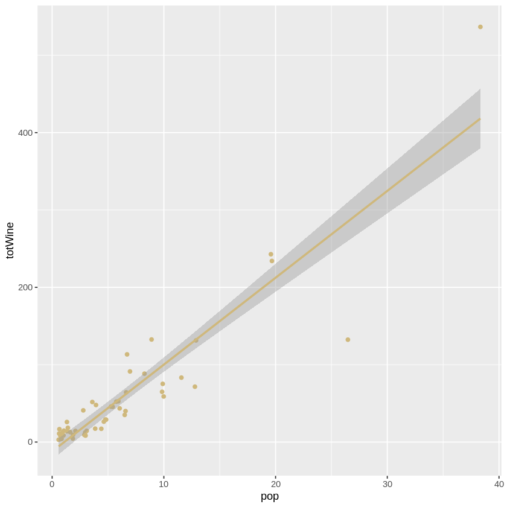

```python
# Your Code Here
wine_lm <- lm(totWine ~ pop, data = wine.data)
wine_plot <- wine_plot + geom_smooth(method='lm', col='#CFB87C', level = 0.90)
wine_plot

single_point <- wine.data[6, ]
single_point

wine_conf <- predict(wine_lm, new = single_point, level = 0.90, interval = "confidence")
wine_conf
```

For the Colorado data point, the best point estimate was 47.01169 million liters of wine. The 90% confidence interval (38.77014, 55.25324) means a 90% certainty that a new US state with a population of 5.267603 million would expect to consume somewhere between 38.77014 million and 55.25324 million liters of wine on average over many resamplings.

#### 1. (c) Prediction Intervals

Using the same `pop` point-value as in **1.b**, plot the prediction interval end points. In words, explain what this interval means for that data point.

A matrix: 1 × 3 of type dbl

|  | fit | lwr | upr |
| --- | --- | --- | --- |
| 6 | 47.01169 | -11.90418 | 105.9276 |

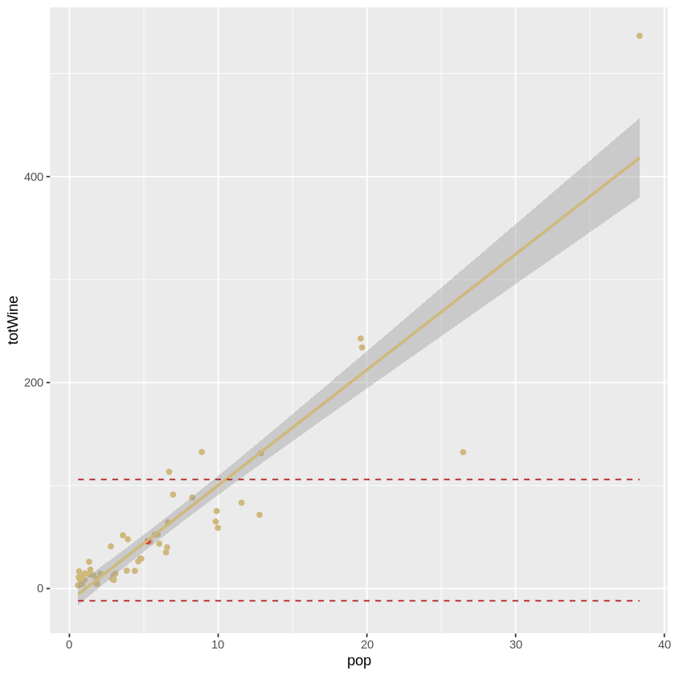

```python
wine_pred <- predict(wine_lm, new = single_point, level = 0.90, interval = "prediction")
wine_pred

pred_plot <- ggplot(data = wine.data, aes(x=pop, y=totWine)) +
                geom_point(color='#CFB87C') +
                geom_point(data = wine.data %>% filter(State == "Colorado"), color = "red") +
                geom_smooth(method='lm', col='#CFB87C', level = 0.90) +
                geom_line(aes(y=wine_pred[ , 2]), color = "firebrick", linetype = "dashed")+
                geom_line(aes(y=wine_pred[ , 3]), color = "firebrick", linetype = "dashed")
pred_plot
```

For the Colorado data point (shown in red), the point estimate is 47.01169 million liters of wine consumed. The 90% prediction interval for the data point is (-11.90418, 105.9276) indicated by the red dashed lines. This means that there is a 90% certainty that a new US state with a population of 5.267603 million would expect to consume somewhere between -11.90418 million and 105.9276 million liters of wine for a single sample of that state. In practical terms, the lower bound would be equivalent to 0 liters of wine consumed because the value cannot be negative. Notice that the prediction interval is much wider than the confidence interval, because the confidence interval tries to figure out the *mean* response and the prediction interval tries to figure out a single response.

#### 1. (d) Some "Consequences" of Linear Regression

As you've probably gathered by now, there is a lot of math that goes into fitting linear models. It's important that you're exposed to these underlying systems and build an intuition for how certain processes work. However, some of the math can be a bit too... tedious for us to make you go through on your own. Below are a list of "consequences" of linear regression, things that are mathematically true because of the assumptions and formulations of the linear model (let $\widehat\varepsilon_i$ be the residuals of the regression model):

1. $\sum \widehat\varepsilon_i = 0$ : The sum of residuals is 0.
2. $\sum \widehat\varepsilon_i^2$ is as small as it can be.
3. $\sum x_i \widehat\varepsilon_i = 0$
4. $\sum \hat{y}_i \widehat\varepsilon_i = 0$ : The Residuals are orthogonal to the fitted values.
5. The Regression Line always goes through $(\bar{x}, \bar{y})$.

Check that your regression model confirms the "consequences" $1,3,4$ and $5$. For consequence $2$, give a logical reason on why this formulation makes sense.

**Note: even if your data agrees with these claims, that does not prove them as fact. For best practice, try to prove these facts yourself!**

```python
e = resid(wine_lm)
fit = fitted(wine_lm)

part_1 <- sum(e)
cat(round(part_1,8), "\n")


#part 2 below code

part_3 <- sum(e * wine.data$pop)
cat(round(part_3,8), "\n")

part_4 <- sum(e * fit)
cat(round(part_4,8), "\n")

#part_5 <- list(mean(wine.data$pop), mean(wine.data$totWine))
#part_5
left <- wine_lm$coefficients[1]
right <- mean(wine.data$totWine) - wine_lm$coefficients[2] * mean(wine.data$pop)
cat(round(right, 8) == round(left,8))
```

```
0
0
0
TRUE
```

The squared sum of residuals $\sum \widehat\varepsilon_i^2$ should logically be minimized because the line of best fit should try to be as close to the data points as possible. If there existed a line that was closer to the data points, then that line would 'fit' the data better and be the line of best fit instead.

The simple linear regression line must pass through the point $(\bar{x}, \bar{y})$ because the OLS parameter estimate for the intercept of the line of best fit is $\hat{\beta_0} = \bar{Y} - \hat{\beta_1}\bar{x}$ .

# Problem 2: Explanation

[figure not shown]

Image Source: https://xkcd.com/552/

Did our wine drinking data come from an experiment or an observational study? Do you think we can infer causation between population and the amount of wine drank from these data?

The wine drinking data comes from an observational study of how much each state naturally drank and what the pre-existing population of that state was. There was no way for the researchers to control the population or to force entire states to drink more or less wine, so it cannot be an experiment. Causality cannot be inferred from observational studies, only correlation and a suggestion of the possibility that there could be a causal relation. A randomized experiment in which scientists are able to control the independent variables with precision would be required.

# Problem 3: Even More Intervals!

We're almost done! There is just a few more details about Confidence Intervals and Perdiction Intervals which we want to go over. How does changing the data affect the confidence interval? That's a hard question to answer with a single dataset, so let's simulate a bunch of different datasets and see what they intervals they produce.

#### 3. (a) Visualize the data

The code cell below generates 20 data points from two different normal distributions. Finish the code by fitting a linear model to the data and plotting the results with ggplot, with Confidence Intervals for the mean and Prediction Intervals included.

Experiment with different means and variances. Does changing these values affect the CI or PI?

```python
gen_data <- function(mu1, mu2, var1, var2){
    # Function to generate 20 data points from 2 different normal distributions.
    x.1 = rnorm(10, mu1, 2)
    x.2 = rnorm(10, mu2, 2)
    y.1 = 2 + 2*x.1 + rnorm(10, 0, var1)
    y.2 = 2 + 2*x.2 + rnorm(10, 0, var2)

    df = data.frame(x=c(x.1, x.2), y=c(y.1, y.2))
    return(df)
}

set.seed(0)
head(gen_data(-8, 8, 10, 10))
```

A data.frame: 6 × 2

|  | x <dbl> | y <dbl> |
| --- | --- | --- |
| 1 | -5.474091 | -11.1908617 |
| 2 | -8.652467 | -11.5309770 |
| 3 | -5.340401 | -7.3474393 |
| 4 | -5.455141 | -0.8683876 |
| 5 | -7.170717 | -12.9125020 |
| 6 | -11.079900 | -15.1237204 |

```
Call:
lm(formula = y ~ x, data = sample)

Residuals:
    Min      1Q  Median      3Q     Max
-13.741  -5.382   1.676   5.124  11.165

Coefficients:
            Estimate Std. Error t value Pr(>|t|)
(Intercept)    0.498      1.515   0.329    0.746
x              2.158      0.183  11.797 6.64e-10 ***
---
Signif. codes:  0 ‘***’ 0.001 ‘**’ 0.01 ‘*’ 0.05 ‘.’ 0.1 ‘ ’ 1

Residual standard error: 6.771 on 18 degrees of freedom
Multiple R-squared:  0.8855,	Adjusted R-squared:  0.8791
F-statistic: 139.2 on 1 and 18 DF,  p-value: 6.636e-10
```

```
Call:
lm(formula = y ~ x, data = sample2)

Residuals:
     Min       1Q   Median       3Q      Max
-15.6059  -7.9961   0.6626   6.5011  16.3985

Coefficients:
            Estimate Std. Error t value Pr(>|t|)
(Intercept)  -0.3838     2.8630  -0.134  0.89484
x             1.5872     0.5213   3.045  0.00697 **
---
Signif. codes:  0 ‘***’ 0.001 ‘**’ 0.01 ‘*’ 0.05 ‘.’ 0.1 ‘ ’ 1

Residual standard error: 9.954 on 18 degrees of freedom
Multiple R-squared:  0.3399,	Adjusted R-squared:  0.3033
F-statistic:  9.27 on 1 and 18 DF,  p-value: 0.006974
```

```
Call:
lm(formula = y ~ x, data = sample3)

Residuals:
    Min      1Q  Median      3Q     Max
-31.155  -5.603  -2.048   5.415  42.597

Coefficients:
            Estimate Std. Error t value Pr(>|t|)
(Intercept)   0.5653     4.3409    0.13    0.898
x             2.1297     0.1226   17.37 1.08e-12 ***
---
Signif. codes:  0 ‘***’ 0.001 ‘**’ 0.01 ‘*’ 0.05 ‘.’ 0.1 ‘ ’ 1

Residual standard error: 15.8 on 18 degrees of freedom
Multiple R-squared:  0.9437,	Adjusted R-squared:  0.9406
F-statistic: 301.7 on 1 and 18 DF,  p-value: 1.083e-12
```

```
Call:
lm(formula = y ~ x, data = sample4)

Residuals:
    Min      1Q  Median      3Q     Max
-0.5570 -0.2668 -0.1129  0.2271  0.9309

Coefficients:
            Estimate Std. Error t value Pr(>|t|)
(Intercept)  2.07200    0.09611   21.56 2.63e-14 ***
x            2.02300    0.04726   42.80  < 2e-16 ***
---
Signif. codes:  0 ‘***’ 0.001 ‘**’ 0.01 ‘*’ 0.05 ‘.’ 0.1 ‘ ’ 1

Residual standard error: 0.4296 on 18 degrees of freedom
Multiple R-squared:  0.9903,	Adjusted R-squared:  0.9897
F-statistic:  1832 on 1 and 18 DF,  p-value: < 2.2e-16
```

```
Call:
lm(formula = y ~ x, data = sample5)

Residuals:
    Min      1Q  Median      3Q     Max
-17.457  -6.896  -1.215   7.035  19.227

Coefficients:
            Estimate Std. Error t value Pr(>|t|)
(Intercept)   3.2058     2.4633   1.301     0.21
x             1.9114     0.1238  15.441 7.93e-12 ***
---
Signif. codes:  0 ‘***’ 0.001 ‘**’ 0.01 ‘*’ 0.05 ‘.’ 0.1 ‘ ’ 1

Residual standard error: 11.02 on 18 degrees of freedom
Multiple R-squared:  0.9298,	Adjusted R-squared:  0.9259
F-statistic: 238.4 on 1 and 18 DF,  p-value: 7.93e-12
```

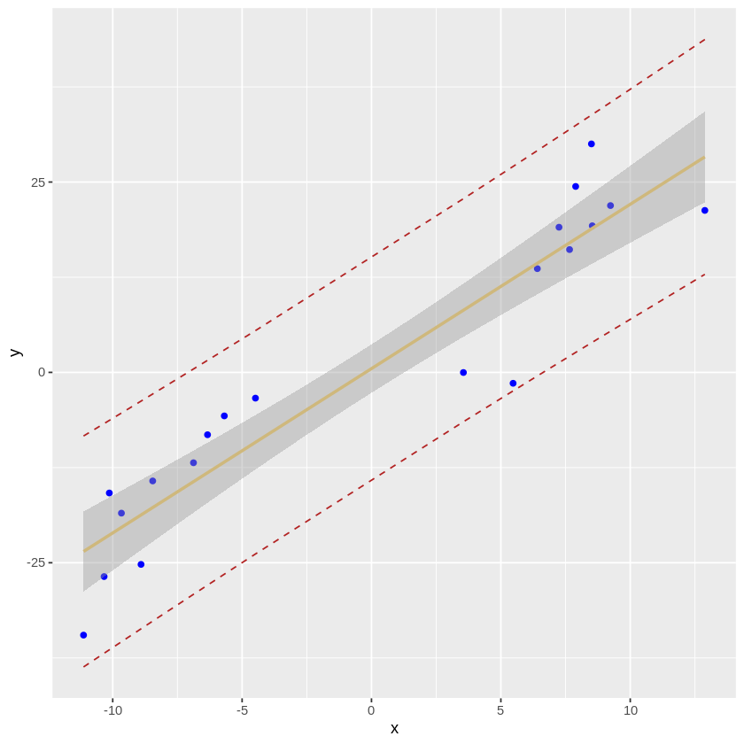

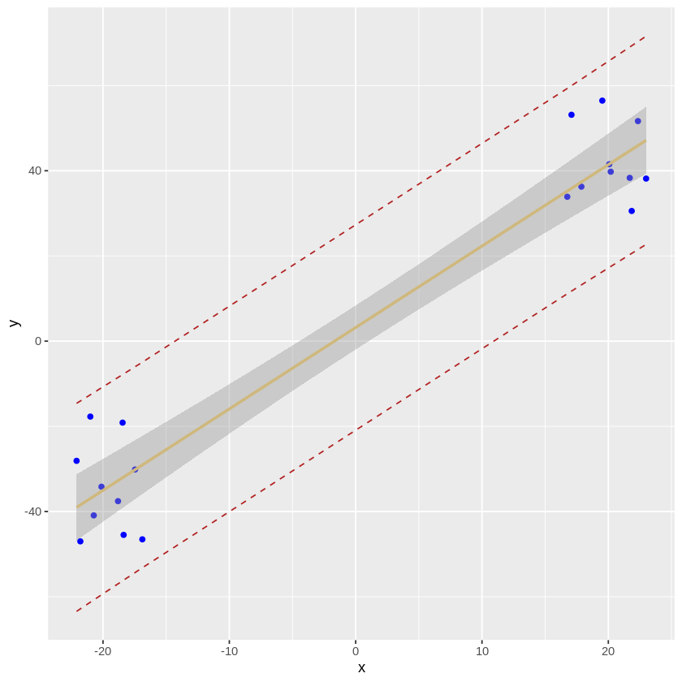

```python
sample <- gen_data(-8, 8, 10, 10)

lm_gen_data <- lm(y ~ x, data = sample)
summary(lm_gen_data)

temp <- predict(lm_gen_data, interval = "prediction", level = 0.95)
full_df <- cbind(sample, temp)

gen_plot <- ggplot(data = full_df, aes(x=x, y=y)) +
                geom_point(color='blue') +
                geom_smooth(method='lm', col='#CFB87C', level = 0.95) +
                geom_line(aes(y=lwr), color = "firebrick", linetype = "dashed")+
                geom_line(aes(y=upr), color = "firebrick", linetype = "dashed")
gen_plot

#Second run

sample2 <- gen_data(-8, 0, 10, 11)

lm_gen_data2 <- lm(y ~ x, data = sample2)
summary(lm_gen_data2)

temp2 <- predict(lm_gen_data2, interval = "prediction", level = 0.95)
full_df2 <- cbind(sample2, temp2)

gen_plot2 <- ggplot(data = full_df2, aes(x=x, y=y)) +
                geom_point(color='blue') +
                geom_smooth(method='lm', col='#CFB87C', level = 0.95) +
                geom_line(aes(y=lwr), color = "firebrick", linetype = "dashed")+
                geom_line(aes(y=upr), color = "firebrick", linetype = "dashed")
#gen_plot2

#Third run

sample3 <- gen_data(-8, 50, 5, 20)

lm_gen_data3 <- lm(y ~ x, data = sample3)
summary(lm_gen_data3)

temp3 <- predict(lm_gen_data3, interval = "prediction", level = 0.95)
full_df3 <- cbind(sample3, temp3)

gen_plot3 <- ggplot(data = full_df3, aes(x=x, y=y)) +
                geom_point(color='blue') +
                geom_smooth(method='lm', col='#CFB87C', level = 0.95) +
                geom_line(aes(y=lwr), color = "firebrick", linetype = "dashed")+
                geom_line(aes(y=upr), color = "firebrick", linetype = "dashed")
#gen_plot3

#Fourth run

sample4 <- gen_data(-1, 1, .5, .5)

lm_gen_data4 <- lm(y ~ x, data = sample4)
summary(lm_gen_data4)

temp4 <- predict(lm_gen_data4, interval = "prediction", level = 0.95)
full_df4 <- cbind(sample4, temp4)

gen_plot4 <- ggplot(data = full_df, aes(x=x, y=y)) +
                geom_point(color='blue') +
                geom_smooth(method='lm', col='#CFB87C', level = 0.95) +
                geom_line(aes(y=lwr), color = "firebrick", linetype = "dashed")+
                geom_line(aes(y=upr), color = "firebrick", linetype = "dashed")
#gen_plot4

#Fifth run
sample5 <- gen_data(-20, 20, 10, 10)

lm_gen_data5 <- lm(y ~ x, data = sample5)
summary(lm_gen_data5)

temp5 <- predict(lm_gen_data5, interval = "prediction", level = 0.95)
full_df5 <- cbind(sample5, temp5)

gen_plot5 <- ggplot(data = full_df5, aes(x=x, y=y)) +
                geom_point(color='blue') +
                geom_smooth(method='lm', col='#CFB87C', level = 0.95) +
                geom_line(aes(y=lwr), color = "firebrick", linetype = "dashed")+
                geom_line(aes(y=upr), color = "firebrick", linetype = "dashed")
gen_plot5
```

#### 3. (b) The Smallest Interval

Recall that the Confidence (Mean) Interval, when the predictor value is $x_k$, is defined as:

$$ \hat{y}_h \pm t_{\alpha/2,n-2} \sqrt{MSE \times \Big( \dfrac{1}{n} + \dfrac{(x_k - \bar{x})^2}{\sum(x_i - \bar{x})} \Big)} $$

where $\hat{y}_h$ is the fitted response for predictor value $x_h$, $t_{\alpha/2,n-2}$ is the t-value with $n-2$ degrees of freedom and $MSE \times \Big( \dfrac{1}{n} + \dfrac{(x_h - \bar{x})^2}{\sum(x_i - \bar{x})} \Big)$ is the standard error of the fit.

From the above equation, what value of $x_k$ would result in the CI with the shortest width? Does this match up with the simulated data? Can you give an intuitive reason for why this occurs?

When $x_k$ is equal to $\bar{x}$, the entire second term in the parentheses becomes 0, which minimizes the term and consequently minimizes the entire interval. This phenomenon matches up with the simulated data. Intuitively, you would be the most confident about data points which were hitting exactly the mean, the place where you would expect points to be on average.

#### 3. (c) Interviewing the Intervals

Recall that the Prediction Interval, when the predictor value is $x_k$, is defined as:

$$ \hat{y}_h \pm t_{\alpha/2,n-2} \sqrt{MSE \Big( 1 + \dfrac{1}{n} + \dfrac{(x_k - \bar{x})^2}{\sum(x_i - \bar{x})} \Big)} $$

Does the "width" of the Prediction Interval change at different population values? Explain why or why not.

Yes, the width of the prediction interval is dependent on $x_k$ in the formula. Since population would be $x_k$ in this scenario, the population value for each state would change the width of the prediction.

## Problem 4: Causality

**Please answer the following three questions. Each answer should be clearly labeled, and a few sentences to a paragraph long.**

1. In your own words, describe the fundamental problem of causal inference. How is this problem related to the counterfactual definition of causality?
1. Describe the use of "close substitutes" as a solution to the fundamental problem of causal inference. How does this solve the problem?
1. What is the difference between a *deterministic* theory of causality and a *probabilistic* theory of causality?
1. The fundamental problem of causal inference is that for any particular scenario, there is only a singular outcome that occurs, so we can never truly know the impact that other potential outcomes could have had. That is to say, we cannot measure causal effects on a unitary scale. The counterfactual theory of causality states that "event A causes event B if in the absence of event A, event B would be less likely to occur or not occur at all." The fundamental problem of causal inference means that we cannot easily find out what would have happened if an event that occurred had instead not occurred, because we can only see one outcome in our true reality. We are not able to collect real data on counterfactual scenarios.
2. Since we cannot gather direct evidence on counterfactual scenarios, the best we can do is find another situation which is as similar as possible but with a one key difference, like a single predictor or event. This allows us to compare situation A to situation A', where A' is a close substitute for A. With two identical backgrounds in every other sense, we can investigate the effect of the one difference across multiple different outcomes.
3. The deterministic theory of causality mandates that if event A causes event B, then the occurrence of event A will always cause event B to occur. There is no uncertainty, events either happen or they don't. If outcomes appear to be stochastic, that is simply an indication that there are more variables at play that have not been taken into account for the model. The probabilistic theory of causality merely says that a cause only has to impact the chances of outcome, but need not necessarily manifest it. For example, increasing the amount of radiation one's body is exposed to will increase the odds that one gets melanoma, but does not guarantee it.

## Problem 5: Causal inference and ethics

How we think about causality, and the statistical models that we use to learn about causal relationships, have ethical implications. The goal of this problem is to invite you to think through some of those issues and implications.

Statisticians, data scientists, researchers, etc., are not in agreement on the best ways to study and analyze important social problems, such as racial discrimination in the criminal justice system. Lily Hu, a PhD candidate in applied math and philosophy at Harvard, [wrote](https://lpeproject.org/blog/law-liberation-and-causal-inference/) that disagreements about how to best study these problems "well illustrate how the nuts and bolts of causal inference...about the quantitative ventures to compute 'effects of race'...feature a slurry of theoretical, empirical, and normative reasoning that is often displaced into debates about purely technical matters in methodology."

Here are some resources that enter into or comment on this debate:

1. [Statistical controversy on estimating racial bias in the criminal justice system](https://statmodeling.stat.columbia.edu/2020/07/06/statistical-controversy-on-racial-bias-in-the-criminal-justice-system/)
2. [Can Racial Bias in Policing Be Credibly Estimated Using Data Contaminated by Post-Treatment Selection?](https://dcknox.github.io/files/KnoxLoweMummolo_PostTreatmentSelectionPolicing.pdf)
3. [A Causal Framework for Observational Studies of Discrimination](https://5harad.com/papers/post-treatment-bias.pdf)

**Please read Lily Hu's [blog post](https://lpeproject.org/blog/law-liberation-and-causal-inference/) and Andrew Gelman's blog post ["Statistical controversy on estimating racial bias in the criminal justice system"](https://statmodeling.stat.columbia.edu/2020/07/06/statistical-controversy-on-racial-bias-in-the-criminal-justice-system/) (and feel free to continue on with the other two papers!) to familiarize yourself with some of the issues in this debate. Then, write a short essay (300-500 words) summarizing this debate. Some important items to consider:**

1. How does the "fundamental problem of causal inference" play out in these discussions?
1. What are some "possible distortionary effect[s] of using arrest data from administrative police records to measure causal effects of race"?
1. What role do assumptions (both statistical and otherwise) play in this debate? To what extent are assumptions made by different researchers falsifiable?

There seem to be two main sides in the debate over applying causal inference to racial data related to criminal justice and its various constructs that exert influence over the public, such as the police force. One group seems to be making the claim that it might not be an issue to perform standard regression on data in a certain point in the justice system becuse there are multiple sources of bias and they could even out to being approximately unbiased. Lily Hu mentions in her blog post that one potential possible scenario could be that one source of bias is that the police are more likely to stop Black people for less severe crimes. This source of bias could be countered by another source of bias, such as encounters between the police and a Black civilian are more likely to become confrontational. The decreased average crime severity combined with the increased average threat level could theoretically mellow each other out to effectively have a non-biased situation. The other main party in the debate says that it is statistically unsound to estimate regression parameters for causal inference when there are sources of upstream bias. For example, using arrest data from administrative police records could easily have bias from the choice of which civilians to stop impacting the set of available potential civilians to arrest. This could distort the causal affects estimated in the arrest records. One overarching issue with settling the debate of whether or not certain methodology violates the conditions of causal inference is that data can never be gathered on the counterfactual scenario, the so-called "fundamental problem of causal inference". For example, if we believe there is bias in an upstream point in the system, there is no way to gather data for the same exact situation in which the bias is removed. This also makes it difficult to falsify claims about bias sources cancelling each other out. For a civilian that was never stopped by the police but was simply being "observed", there would be no way to observe the scenario in which the civilian had actually been stopped and gather data on the outcome. Hu mentions that because causal inference requires a certain set of assumptions on the part of the researcher, the ability to claim that the causal estimates are valid depends heavily on the researcher's own views. Namely, Hu writes "whether policing is racially discriminatory depends on one’s prior views about which differences across racial groups are the 'relevant' differences that do and do not 'justify' differential police treatment."